# Data Tidak Stasioner

2023-09-23

```r
library(ggplot2)
library(tsibble)
library(tseries)
library(MASS)
library(tseries)
library(forecast)
library(TTR)
library(TSA)
library(imputeTS)
library(ggplot2)
library(lmtest)
set.seed(1002)
```

## IMPORT DATA

```r
library(rio)
data <- import ("https://raw.githubusercontent.com/divanm/mpdw/main/Data/DATA%20IDX%20COMPOSITE%20JKSE.csv")
x <- data$Open
y <- data$Close
```

# Cek apakah ada missing value:

```r
data[which(is.na(data$Close)),]
```

```
##           Date Open High Low Close Adj Close Volume
## 109 2022-05-02   NA   NA  NA    NA        NA     NA
```

## Menduga missing value

```r
data <- na_interpolation(data, option = "spline")
data
```

```
##           Date     Open     High      Low    Close Adj Close     Volume
## 1   2020-04-06 4623.429 4975.536 4562.902 4649.079  4649.079  255758500
## 2   2020-04-13 4649.079 4747.725 4480.607 4634.821  4634.821  218419900
## 3   2020-04-20 4634.821 4669.542 4441.090 4496.064  4496.064  238397200
## 4   2020-04-27 4496.064 4726.774 4474.893 4716.403  4716.403  183906700
## 5   2020-05-04 4716.403 4716.403 4576.228 4597.430  4597.430  179791700
## 6   2020-05-11 4597.430 4659.862 4460.273 4507.607  4507.607  231060000
## 7   2020-05-18 4507.607 4609.042 4487.179 4545.952  4545.952  139287000
## 8   2020-05-25 4545.952 4755.957 4541.834 4753.612  4753.612  288083800
## 9   2020-06-01 4753.612 5014.764 4753.612 4947.782  4947.782  372565600
## 10  2020-06-08 4947.782 5139.406 4712.073 4880.359  4880.359  490084700
## 11  2020-06-15 4880.359 5018.985 4809.619 4942.275  4942.275  336775500
## 12  2020-06-22 4942.275 4977.651 4879.133 4904.088  4904.088  260206800
## 13  2020-06-29 4904.088 4997.482 4862.041 4973.794  4973.794  249816600
## 14  2020-07-06 4973.794 5111.564 4973.490 5031.256  5031.256  358094500
```

[output cut: 129 more lines]

```r
data[109,]
```

```
##           Date    Open     High      Low    Close Adj Close    Volume
## 109 2022-05-02 7324.78 7258.343 6799.028 6840.217  6840.217 697324161
```

```r
stas <- ts(data$Close)
```

### Plot *Time Series*

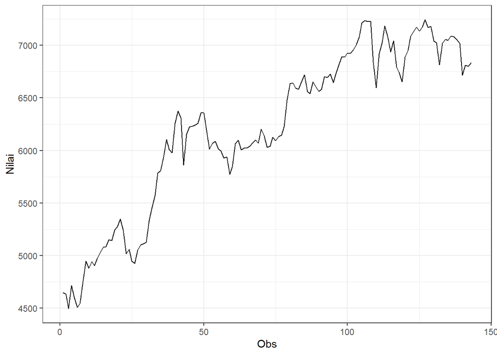

```r
plot_stas <- stas |> as_tsibble() |>
  ggplot(aes(x = index, y = value)) + geom_line() + theme_bw() +
  xlab("Obs") + ylab("Nilai")
plot_stas
```

```r
mean(stas)
```

```
## [1] 6200.346
```

Plot deret waktu di atas menunjukkan bahwa data tidak stasioner dalam rataan, ditandai dengan data yang memiliki pola tren.

### Plot ACF

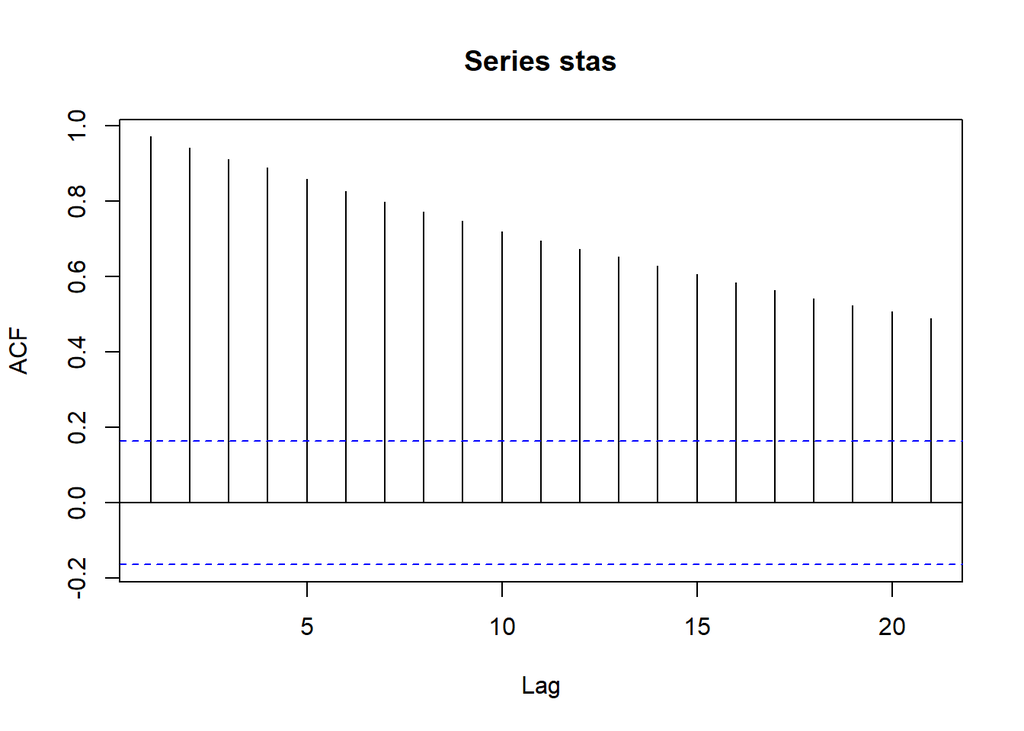

```r
acf(stas)
```

Berdasarkan plot ACF, terlihat bahwa plot ACF pada data tersebut cenderung *tails off slowly*sehingga berdasarkan plot ACF data tidak stasioner.

### Uji ADF

```r
tseries::adf.test(stas)
```

```
##
##  Augmented Dickey-Fuller Test
##
## data:  stas
## Dickey-Fuller = -2.291, Lag order = 5, p-value = 0.4553
## alternative hypothesis: stationary
```

$H_0$ : Data tidak stasioner dalam rataan

$H_1$ : Data stasioner dalam rataan

Berdasarkan uji ADF tersebut, didapat *p-value* sebesar 0.4553 yang lebih besar dari taraf nyata 5% sehingga tak tolak $H_0$ dan menandakan bahwa data tidak stasioner dalam rataan. Hal ini sesuai dengan hasil eksplorasi menggunakan plot time series dan plot ACF.

### Plot Box-Cox

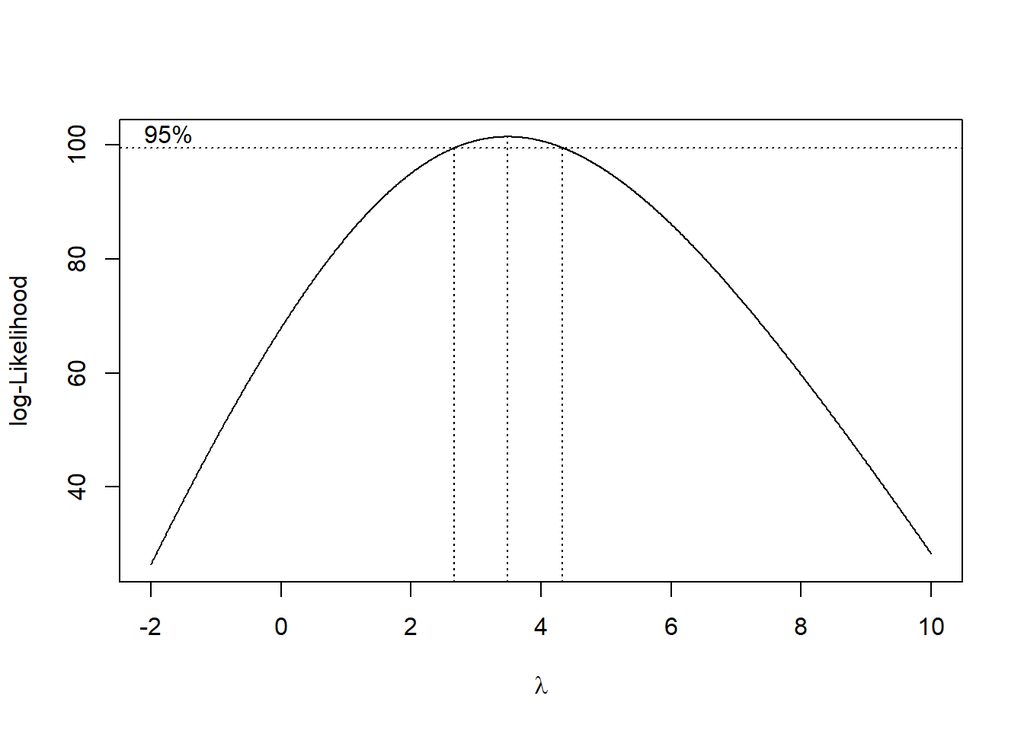

```r
index <- seq(1:143)
bc = boxcox(stas~index, lambda = seq(-2,10,by=0.01))
```

```r
#Nilai Rounded Lambda
lambda <- bc$x[which.max(bc$y)]
lambda
```

```
## [1] 3.49
```

```r
#SK
bc$x[bc$y > max(bc$y) - 1/2 * qchisq(.95,1)]
```

```
##   [1] 2.67 2.68 2.69 2.70 2.71 2.72 2.73 2.74 2.75 2.76 2.77 2.78 2.79 2.80 2.81
##  [16] 2.82 2.83 2.84 2.85 2.86 2.87 2.88 2.89 2.90 2.91 2.92 2.93 2.94 2.95 2.96
##  [31] 2.97 2.98 2.99 3.00 3.01 3.02 3.03 3.04 3.05 3.06 3.07 3.08 3.09 3.10 3.11
##  [46] 3.12 3.13 3.14 3.15 3.16 3.17 3.18 3.19 3.20 3.21 3.22 3.23 3.24 3.25 3.26
##  [61] 3.27 3.28 3.29 3.30 3.31 3.32 3.33 3.34 3.35 3.36 3.37 3.38 3.39 3.40 3.41
##  [76] 3.42 3.43 3.44 3.45 3.46 3.47 3.48 3.49 3.50 3.51 3.52 3.53 3.54 3.55 3.56
##  [91] 3.57 3.58 3.59 3.60 3.61 3.62 3.63 3.64 3.65 3.66 3.67 3.68 3.69 3.70 3.71
## [106] 3.72 3.73 3.74 3.75 3.76 3.77 3.78 3.79 3.80 3.81 3.82 3.83 3.84 3.85 3.86
## [121] 3.87 3.88 3.89 3.90 3.91 3.92 3.93 3.94 3.95 3.96 3.97 3.98 3.99 4.00 4.01
## [136] 4.02 4.03 4.04 4.05 4.06 4.07 4.08 4.09 4.10 4.11 4.12 4.13 4.14 4.15 4.16
## [151] 4.17 4.18 4.19 4.20 4.21 4.22 4.23 4.24 4.25 4.26 4.27 4.28 4.29 4.30 4.31
## [166] 4.32
```

### Partisi Data

#### Bagian 1

```r
dt_stas1 <- stas[1:90] |> ts()
mean(dt_stas1)
```

```
## [1] 5753.671
```

```r
var(dt_stas1)
```

```
## [1] 402891.1
```

#### Plot Time Series

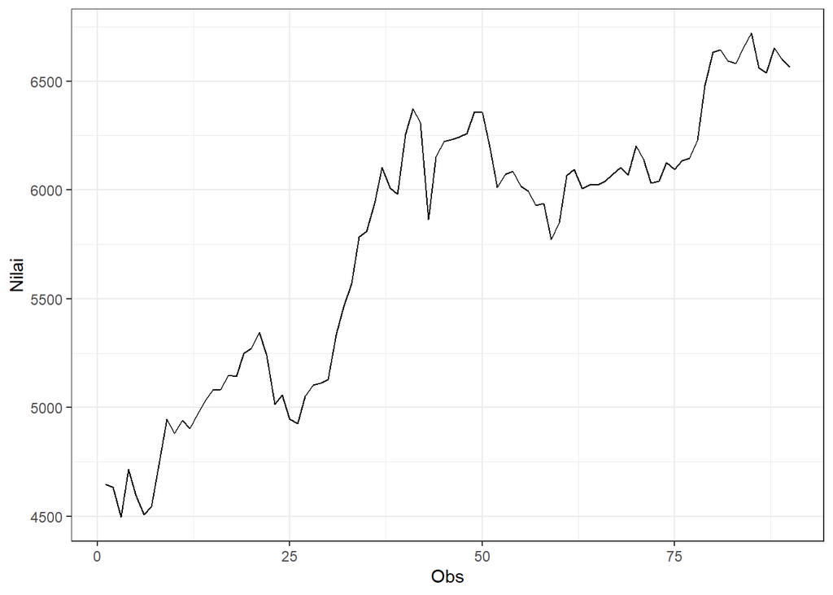

```r
dt_stas1 |> as_tsibble() |>
  ggplot(aes(x = index, y = value)) +
  geom_line() + theme_bw() +
  xlab("Obs") + ylab("Nilai")
```

Plot deret waktu di atas menunjukkan bahwa data tidak stasioner dalam rataan, ditandai dengan data berpola tren naik.

#### Plot ACF

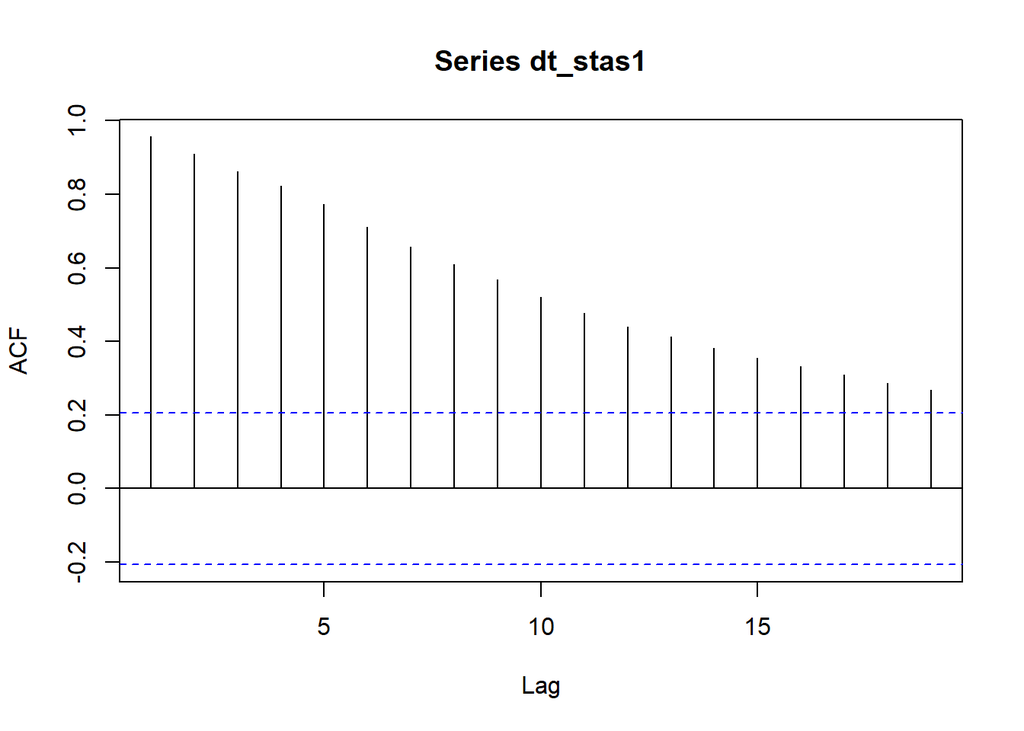

```r
acf(dt_stas1)
```

```r
tseries::adf.test(dt_stas1)
```

```
##
##  Augmented Dickey-Fuller Test
##
## data:  dt_stas1
## Dickey-Fuller = -2.3111, Lag order = 4, p-value = 0.4481
## alternative hypothesis: stationary
```

$H_0$ : Data tidak stasioner dalam rataan

$H_1$ : Data stasioner dalam rataan

Berdasarkan uji ADF tersebut, didapat *p-value* sebesar 0.4481 yang lebih besar dari taraf nyata 5% sehingga tak tolak $H_0$ dan menandakan bahwa data tidak stasioner dalam rataan. Hal ini sesuai dengan hasil eksplorasi menggunakan plot time series dan plot ACF.

#### Plot Boxcox

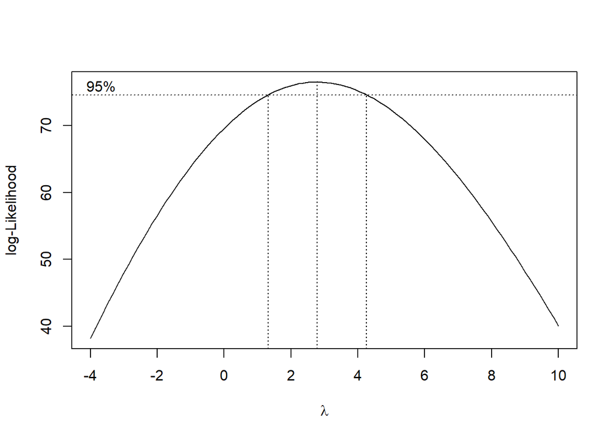

```r
index <- seq(1:90)
bc = boxcox(dt_stas1~index, lambda = seq(-4,10,by=1))
```

```r
#Nilai Rounded Lambda
lambda <- bc$x[which.max(bc$y)]
lambda
```

```
## [1] 2.787879
```

```r
#SK
bc$x[bc$y > max(bc$y) - 1/2 * qchisq(.95,1)]
```

```
##  [1] 1.373737 1.515152 1.656566 1.797980 1.939394 2.080808 2.222222 2.363636
##  [9] 2.505051 2.646465 2.787879 2.929293 3.070707 3.212121 3.353535 3.494949
## [17] 3.636364 3.777778 3.919192 4.060606 4.202020
```

Gambar di atas menunjukkan nilai *rounded value* ($\lambda$) optimum sebesar **2.787879** dan pada selang kepercayaan 95% nilai memiliki batas bawah **1.373737** dan batas atas **4.202020**. Selang tersebuttidak memuat nilai satu sehingga dapat dikatakan bahwa data tidak stasioner dalam ragam.

#### Bagian 2

```r
dt_stas2 <- stas[1:130] |> ts()
mean(dt_stas2)
```

```
## [1] 6125.238
```

```r
var(dt_stas2)
```

```
## [1] 603129.4
```

#### Plot Time Series

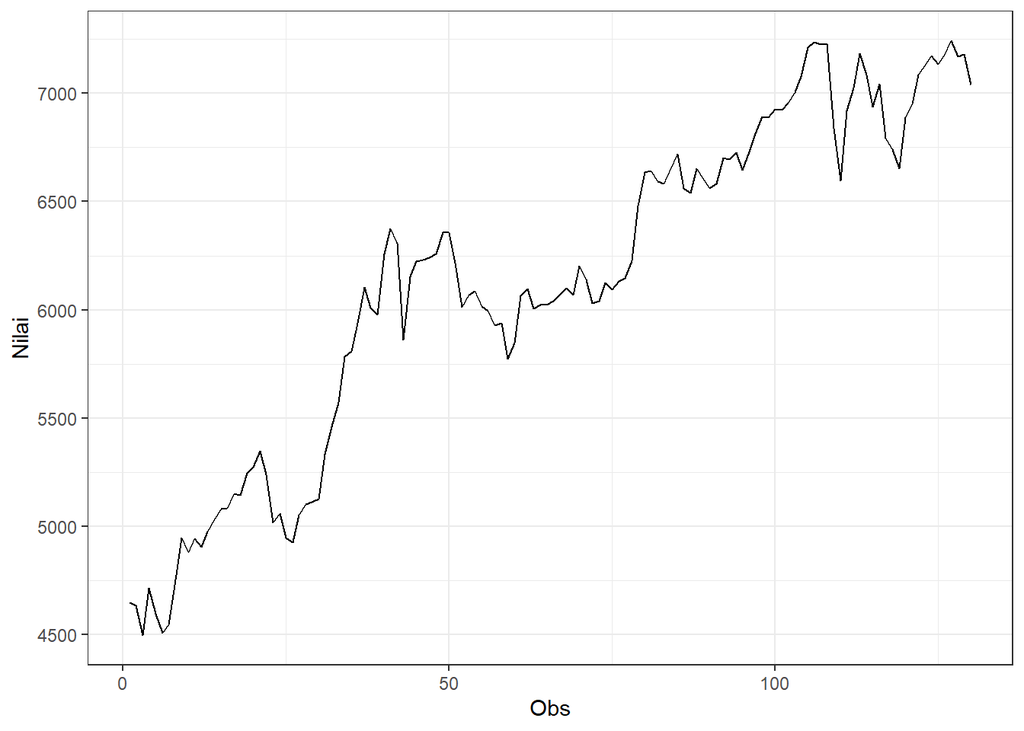

```r
dt_stas2 |> as_tsibble() |>
  ggplot(aes(x = index, y = value)) +
  geom_line() + theme_bw() +
  xlab("Obs") + ylab("Nilai")
```

Plot deret waktu di atas menunjukkan bahwa data tidak stasioner dalam rataan, ditandai dengan data yang berpola tren naik.

#### Plot ACF

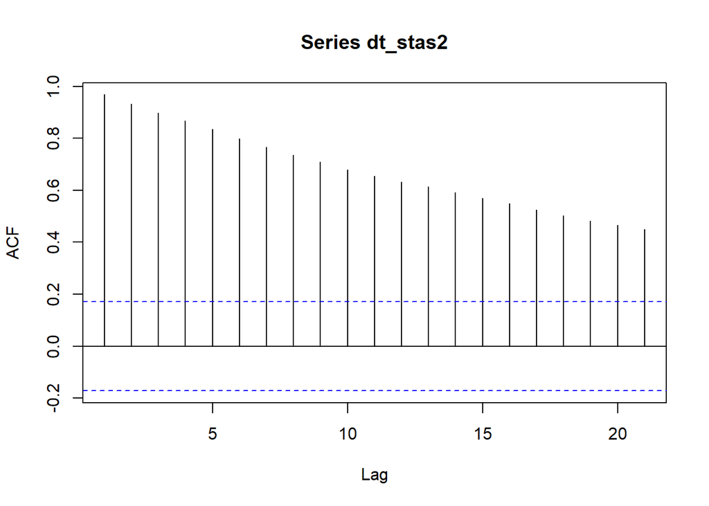

```r
acf(dt_stas2)
```

Berdasarkan plot ACF, terlihat bahwa plot ACF pada data tersebut cenderung *tails off slowly*

#### Uji ADF

```r
adf.test(dt_stas2)
```

```
##
##  Augmented Dickey-Fuller Test
##
## data:  dt_stas2
## Dickey-Fuller = -2.8358, Lag order = 5, p-value = 0.229
## alternative hypothesis: stationary
```

$H_0$ : Data tidak stasioner dalam rataan

$H_1$ : Data stasioner dalam rataan

Berdasarkan uji ADF tersebut, didapat *p-value* sebesar 0.229 yang lebih besar dari taraf nyata 5% sehingga tak tolak $H_0$ dan menandakan bahwa data tidak stasioner dalam rataan. Hal ini sesuai dengan hasil eksplorasi menggunakan plot time series dan plot ACF.

#### Plot Boxcox

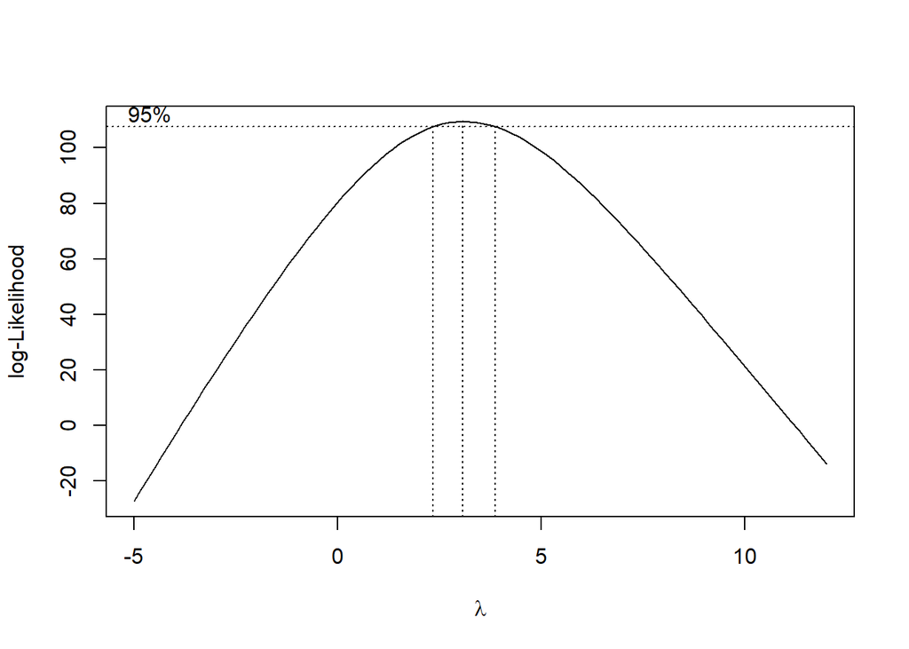

```r
index <- seq(1:130)
bc = boxcox(dt_stas2~index, lambda = seq(-5,12,by=1))
```

```r
#Nilai Rounded Lambda
lambda <- bc$x[which.max(bc$y)]
lambda
```

```
## [1] 3.070707
```

```r
#SK
bc$x[bc$y > max(bc$y) - 1/2 * qchisq(.95,1)]
```

```
## [1] 2.383838 2.555556 2.727273 2.898990 3.070707 3.242424 3.414141 3.585859
## [9] 3.757576
```

Gambar di atas menunjukkan nilai *rounded value* ($\lambda$) optimum sebesar **3.070707** dan pada selang kepercayaan 95% nilai memiliki batas bawah **2.383838** dan batas atas **3.757576**. Selang tersebut tidak memuat nilai satu sehingga dapat dikatakan bahwa data tidak stasioner dalam ragam.